# Ejemplo Didáctico de Propensity Score

Mariana Vaena - marianavaena@gmail.com

# 1 Introducción

Este documento muestra diferentes formas de utilizar el **Propensity Score (PS)** con una base ficticia de pacientes tratados y no tratados.

Incluye:

1. **Ajuste por PS como covariable**
2. **Matching por PS**
3. **Ponderación IPTW (Inverse Probability of Treatment Weighting)**

Variables disponibles:

- `tratamiento` (dicotómica, 0/1)
- `mortalidad` (dicotómica, 0/1)
- `edad` (contínua)
- `sexo` (dicotómica, 0/1)
- `charlson` (contínua)
- `sofa_total` (contínua)

# 2 Preparación: paquetes y datos

Paquetes

```r
library(tidyverse)
library(tableone)
library(MatchIt)
library(cobalt)
library(survey)
library(broom)
```

Carga de la base de datos Ajustar la ruta al archivo CSV según tu repositorio

```r
datos <- read.csv("prueba.csv")
```

Revisar siempre estar usando las variables con formatos correctos

```r
datos <- datos %>%
  mutate(
    tratamiento = as.factor(tratamiento),
    mortalidad  = as.factor(mortalidad),
    sexo        = as.factor(sexo)
  )
```

# 3 Tabla 1 – Comparación basal

```r
vars <- c("edad", "sexo", "charlson", "sofa_total")

tab1 <- CreateTableOne(
  vars = vars,
  strata = "tratamiento",
  data = datos,
  factorVars = c("sexo")
)

tab1
```

```
##                         Stratified by tratamiento
##                          0             1             p      test
##   n                        127           173
##   edad (mean (SD))       58.15 (11.54) 61.93 (12.16)  0.007
##   sexo = 1 (%)              70 (55.1)    111 (64.2)   0.144
##   charlson (mean (SD))    1.57 (1.36)   2.39 (1.56)  <0.001
##   sofa_total (mean (SD))  8.51 (3.16)  10.39 (3.16)  <0.001
```

**Interpretación**

- La edad media y los puntajes de gravedad son mayores en tratados.
- Sexo no está perfectamente balanceado.
- **Existe desequilibrio basal → se necesita ajustar.**

# 4 Modelo crudo (sin ajuste)

```r
mod_crudo <- glm(
  mortalidad ~ tratamiento,
  data = datos,
  family = binomial
)

tidy(mod_crudo, exponentiate = TRUE, conf.int = TRUE)
```

```
## # A tibble: 2 × 7
##   term         estimate std.error statistic  p.value conf.low conf.high
##   <chr>           <dbl>     <dbl>     <dbl>    <dbl>    <dbl>     <dbl>
## 1 (Intercept)     0.233     0.227    -6.43  1.30e-10    0.146     0.357
## 2 tratamiento1    0.864     0.305    -0.479 6.32e- 1    0.476     1.58
```

**Interpretación**

- Este modelo estima el efecto crudo del tratamiento sobre la mortalidad.
- El OR crudo del tratamiento sobre mortalidad no es significativo.
- Puede deberse a **sesgo de indicación**: si los más graves tienen mas chances de recibir el tratamiento, pero a la vez los mas graves tienen mas mortalidad, puede atenuarse el verdadero efecto del tratamiento sobre la mortalidad

# 5 Estimación del Propensity Score

Para la estimación, también hacemos un modelo de regresión logística

Pero esta vez, la variable dependiente del modelo es el tratamiento.

```r
ps_model <- glm(
  tratamiento ~ edad + sexo + charlson + sofa_total,
  data = datos,
  family = binomial
)

datos$ps <- predict(ps_model, type = "response")
summary(datos$ps)
```

```
##    Min. 1st Qu.  Median    Mean 3rd Qu.    Max.
## 0.07038 0.42471 0.58346 0.57667 0.75905 0.98896
```

Distribución del PS por grupo

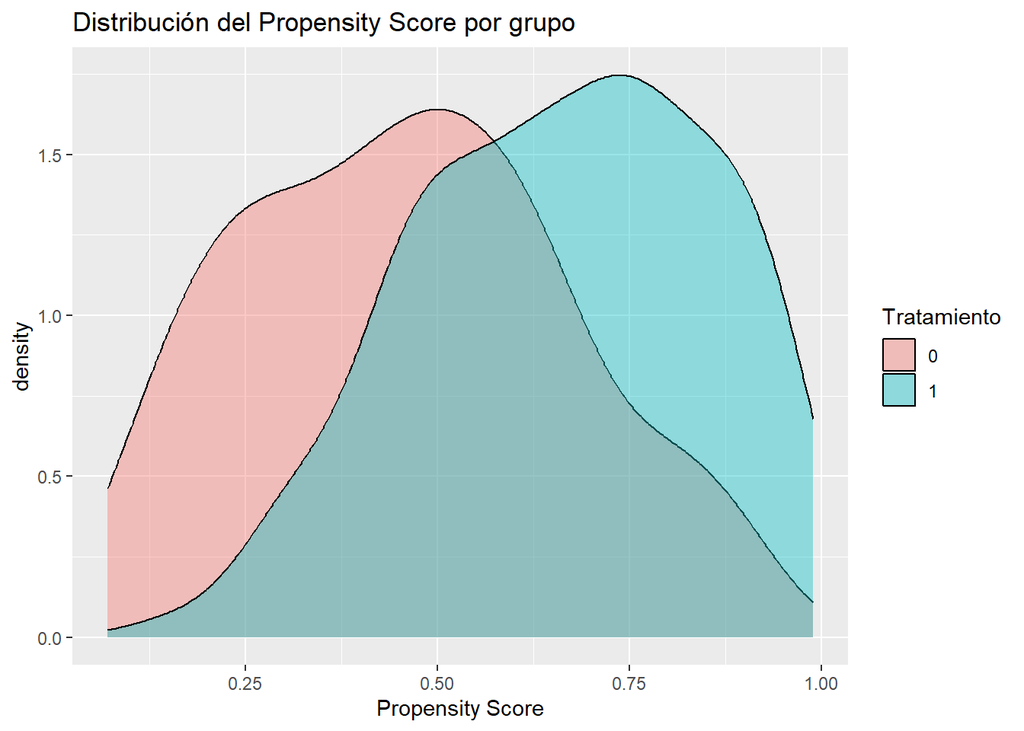

```r
ggplot(datos, aes(ps, fill = tratamiento)) +
  geom_density(alpha = 0.4) +
  labs(
    title = "Distribución del Propensity Score por grupo",
    fill = "Tratamiento",
    x = "Propensity Score"
  )
```

**Interpretación**

- Se observa solapamiento aceptable entre grupos.
- Sin embargo, los tratados tienden a tener valores más altos de PS, consistente con mayor carga de enfermedad.
- Esto permite aplicar métodos basados en PS.

## 5.1 **Uso 1 — Ajuste por PS como covariable**

```r
mod_ps_cov <- glm(
  mortalidad ~ tratamiento + ps,
  data = datos,
  family = binomial
)

tidy(mod_ps_cov, exponentiate = TRUE, conf.int = TRUE)
```

```
## # A tibble: 3 × 7
##   term         estimate std.error statistic  p.value conf.low conf.high
##   <chr>           <dbl>     <dbl>     <dbl>    <dbl>    <dbl>     <dbl>
## 1 (Intercept)    0.0203     0.582     -6.69 2.26e-11  0.00602    0.0595
## 2 tratamiento1   0.343      0.369     -2.90 3.76e- 3  0.164      0.701
## 3 ps           110.         0.930      5.05 4.31e- 7 19.2      746.
```

**Comentarios metodológicos**

- Resume múltiples confusores en una sola variable → simplifica el modelo.
- Estima un **efecto condicional**, no marginal.

**Interpretación**

- Tras ajustar por el PS, el OR del tratamiento cambia notablemente: esto indica que el modelo crudo sufría confusión
- En esta base, el tratamiento parece asociado a menor mortalidad después del ajuste, lo cual es consistente con una minimización del sesgo de indicación.

## 5.2 **Uso 2 — Matching por Propensity Score**

```r
mod.match <- matchit(
  tratamiento ~ edad + sexo + charlson + sofa_total,
  data = datos,
  method = "nearest",
  distance = "logit",
  ratio = 1,
  caliper = 0.05
)

summary(mod.match)
```

```
##
## Call:
## matchit(formula = tratamiento ~ edad + sexo + charlson + sofa_total,
##     data = datos, method = "nearest", distance = "logit", caliper = 0.05,
##     ratio = 1)
##
## Summary of Balance for All Data:
##            Means Treated Means Control Std. Mean Diff. Var. Ratio eCDF Mean
## distance          0.6630        0.4590          1.0689     0.8185    0.2579
## edad             61.9324       58.1488          0.3112     1.1103    0.0849
## sexo0             0.3584        0.4488         -0.1886          .    0.0904
## sexo1             0.6416        0.5512          0.1886          .    0.0904
## charlson          2.3873        1.5669          0.5256     1.3165    0.1025
## sofa_total       10.3931        8.5118          0.5947     1.0010    0.1036
##            eCDF Max
## distance     0.3781
## edad         0.1703
## sexo0        0.0904
## sexo1        0.0904
## charlson     0.3036
## sofa_total   0.2725
##
## Summary of Balance for Matched Data:
##            Means Treated Means Control Std. Mean Diff. Var. Ratio eCDF Mean
## distance          0.5645        0.5596          0.0258     1.0143    0.0097
## edad             60.4279       59.8023          0.0514     1.1753    0.0298
## sexo0             0.3837        0.4186         -0.0727          .    0.0349
## sexo1             0.6163        0.5814          0.0727          .    0.0349
## charlson          2.0000        1.8837          0.0745     1.1604    0.0465
## sofa_total        9.2209        9.5233         -0.0956     0.8199    0.0207
##            eCDF Max Std. Pair Dist.
## distance     0.0465          0.0314
## edad         0.0814          1.0437
## sexo0        0.0349          1.0427
## sexo1        0.0349          1.0427
## charlson     0.1163          0.7152
## sofa_total   0.0698          0.8087
##
## Sample Sizes:
##           Control Treated
## All           127     173
## Matched        86      86
## Unmatched      41      87
## Discarded       0       0
```

Crear base emparejada

```r
datos_match <- match.data(mod.match)
```

Calcular el OR

```r
mod_ps_match <- glm(
  mortalidad ~ tratamiento,
  data = datos_match,
  family = binomial
)
tidy(mod_ps_match, exponentiate = TRUE, conf.int = TRUE)
```

```
## # A tibble: 2 × 7
##   term         estimate std.error statistic    p.value conf.low conf.high
##   <chr>           <dbl>     <dbl>     <dbl>      <dbl>    <dbl>     <dbl>
## 1 (Intercept)     0.284     0.260     -4.85 0.00000124    0.166     0.462
## 2 tratamiento1    0.572     0.405     -1.38 0.168         0.252     1.25
```

**Interpretación**

- El matching crea una pseudo-población donde la distribución de confusores debería ser similar entre tratados y no tratados.
- El estimando típico es el ATT (Average Treatment effect on the Treated).
- En esta base, el OR en la muestra emparejada muestra una reducción en la mortalidad del tratamiento
- Sin embargo, pierde poder estadístico por reducción de muestra. Esto ocurre porque el matching 1:1 descarta observaciones sin pareja válida

## 5.3 **Uso 3 — IPTW (Inverse Probability of Treatment Weighting)***

Primero se deben calcular los pesos

```r
datos <- datos %>%
  mutate(
    tratamiento_num = as.numeric(as.character(tratamiento)),
    mortalidad_num  = as.numeric(as.character(mortalidad)),
    iptw = ifelse(tratamiento_num == 1,
                  1 / ps,
                  1 / (1 - ps))
  )

summary(datos$iptw)
```

```
##    Min. 1st Qu.  Median    Mean 3rd Qu.    Max.
##   1.011   1.299   1.613   1.992   2.149  12.120
```

! ojo, vemos que hay valores extremos de hasta 12. Algunos autores recomiendan truncamiento de pesos extremos.

Revisar el balance luego de ponderar

```r
bal.tab(
  x = tratamiento ~ edad + sexo + charlson + sofa_total,
  data = datos,
  weights = datos$iptw,
  method = "weighting"
)
```

```
## Balance Measures
##               Type Diff.Adj
## edad       Contin.  -0.0329
## sexo        Binary   0.0287
## charlson   Contin.   0.0273
## sofa_total Contin.   0.0459
##
## Effective sample sizes
##            Control Treated
## Unadjusted  127.    173.
## Adjusted     81.44  145.76
```

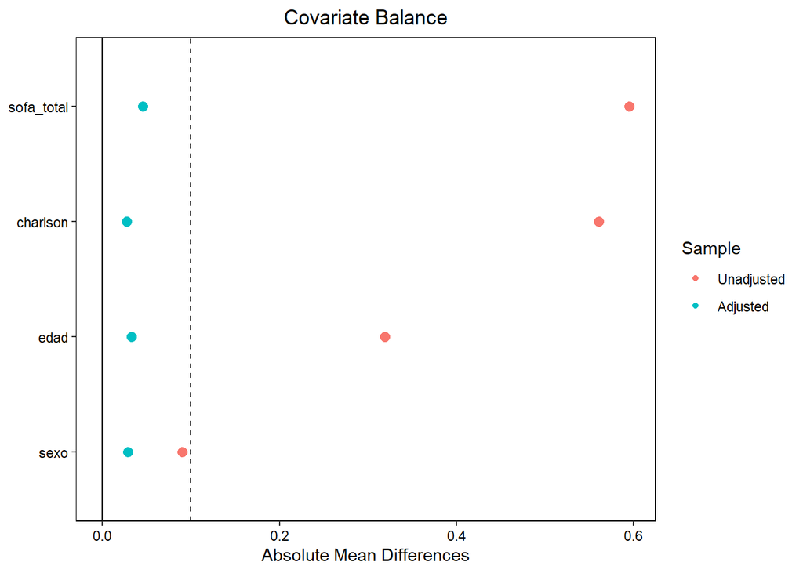

```r
love.plot(
  x = tratamiento ~ edad + sexo + charlson + sofa_total,
  data = datos,
  weights = datos$iptw,
  stats = "mean.diffs",
  threshold = 0.1,
  abs = TRUE,
  var.order = "unadjusted"
)
```

Modelo ponderado (ATE)

```r
design_iptw <- svydesign(
  ids = ~1,
  weights = ~iptw,
  data = datos
)

mod_iptw <- svyglm(
  mortalidad_num ~ tratamiento_num,
  design = design_iptw,
  family = quasibinomial()
)

tidy(mod_iptw, exponentiate = TRUE, conf.int = TRUE)
```

```
## # A tibble: 2 × 7
##   term            estimate std.error statistic p.value conf.low conf.high
##   <chr>              <dbl>     <dbl>     <dbl>   <dbl>    <dbl>     <dbl>
## 1 (Intercept)        0.487     0.277     -2.60 0.00977    0.282     0.839
## 2 tratamiento_num    0.319     0.349     -3.27 0.00119    0.161     0.634
```

**Interpretación**

- Los pesos producen una “pseudo-población” donde la distribución de confusores es equilibrada.
- Tras IPTW, el balance de las medias estandarizadas de las variables confusoras mejora notablemente.
- En esta base, el efecto del tratamiento se hace más evidente y estadísticamente significativo.
- IPTW tiende a conservar mayor n que el matching y estimar el ATE.